# Instacart Market Basket Analysis

## Project Overview

This project explores customer shopping behavior using Instacart's grocery shopping dataset. Through comprehensive exploratory data analysis (EDA), we uncover patterns in when customers shop, what they buy, and how often they reorder products.

## Objectives

- Analyze shopping patterns by time of day and day of week
- Identify the most popular products and categories
- Examine customer reordering behavior
- Understand typical basket sizes and composition

## Dataset

The analysis uses five interconnected datasets:

- **orders**: Customer order history with timestamps
- **products**: Product catalog with names and categories
- **departments**: Department classifications
- **aisles**: Aisle classifications
- **order_products**: Products included in each order

## Key Findings

This analysis reveals insights into grocery shopping habits that can inform:

- Inventory management and stock optimization
- Marketing campaign timing
- Product recommendation systems
- Customer retention strategies

# Instacart Market Basket Analysis

## Importing the required libraries

```python
# Import the libraries you'll need for this analysis
import pandas as pd
import matplotlib.pyplot as plt
```

```python
# Load the datasets
# Note: These files use semicolon (;) as the separator instead of comma

orders         = pd.read_csv('datasets/instacart_orders.csv', sep=';')
products       = pd.read_csv('datasets/products.csv', sep=';')
departments    = pd.read_csv('datasets/departments.csv', sep=';')
aisles         = pd.read_csv('datasets/aisles.csv', sep=';')
order_products = pd.read_csv('datasets/order_products.csv', sep=';')
```

## Analyze your data

Examining the structure and content of each dataset using `.info()` and `.head()` methods to understand data types, null counts, and sample values.

```python
# Display orders dataset
orders
```

|  | order_id | user_id | order_number | order_dow | order_hour_of_day | days_since_prior_order |
| --- | --- | --- | --- | --- | --- | --- |
| 0 | 1515936 | 183418 | 11 | 6 | 13 | 30.0 |
| 1 | 1690866 | 163593 | 5 | 5 | 12 | 9.0 |
| 2 | 1454967 | 39980 | 4 | 5 | 19 | 2.0 |
| 3 | 1768857 | 82516 | 56 | 0 | 20 | 10.0 |
| 4 | 3007858 | 196724 | 2 | 4 | 12 | 17.0 |
| ... | ... | ... | ... | ... | ... | ... |
| 478962 | 3210681 | 5617 | 5 | 1 | 14 | 7.0 |
| 478963 | 3270802 | 112087 | 2 | 3 | 13 | 6.0 |
| 478964 | 885349 | 82944 | 16 | 2 | 11 | 6.0 |
| 478965 | 216274 | 4391 | 3 | 3 | 8 | 8.0 |
| 478966 | 2071924 | 1730 | 18 | 1 | 14 | 15.0 |

478967 rows × 6 columns

```python
# Display products dataset
products
```

|  | product_id | product_name | aisle_id | department_id |
| --- | --- | --- | --- | --- |
| 0 | 1 | Chocolate Sandwich Cookies | 61 | 19 |
| 1 | 2 | All-Seasons Salt | 104 | 13 |
| 2 | 3 | Robust Golden Unsweetened Oolong Tea | 94 | 7 |
| 3 | 4 | Smart Ones Classic Favorites Mini Rigatoni Wit... | 38 | 1 |
| 4 | 5 | Green Chile Anytime Sauce | 5 | 13 |
| ... | ... | ... | ... | ... |
| 49689 | 49690 | HIGH PERFORMANCE ENERGY DRINK | 64 | 7 |
| 49690 | 49691 | ORIGINAL PANCAKE & WAFFLE MIX | 130 | 14 |
| 49691 | 49692 | ORGANIC INSTANT OATMEAL LIGHT MAPLE BROWN SUGAR | 130 | 14 |
| 49692 | 49693 | SPRING WATER BODY WASH | 127 | 11 |
| 49693 | 49694 | BURRITO- STEAK & CHEESE | 38 | 1 |

49694 rows × 4 columns

### Examining All Datasets

Reviewing each dataset systematically to understand the structure, column types, and data quality.

```python
departments
```

|  | department_id | department |
| --- | --- | --- |
| 0 | 1 | frozen |
| 1 | 2 | other |
| 2 | 3 | bakery |
| 3 | 4 | produce |
| 4 | 5 | alcohol |
| 5 | 6 | international |
| 6 | 7 | beverages |
| 7 | 8 | pets |
| 8 | 9 | dry goods pasta |
| 9 | 10 | bulk |
| 10 | 11 | personal care |
| 11 | 12 | meat seafood |
| 12 | 13 | pantry |
| 13 | 14 | breakfast |
| 14 | 15 | canned goods |
| 15 | 16 | dairy eggs |
| 16 | 17 | household |
| 17 | 18 | babies |
| 18 | 19 | snacks |
| 19 | 20 | deli |
| 20 | 21 | missing |

```python
aisles
```

|  | aisle_id | aisle |
| --- | --- | --- |
| 0 | 1 | prepared soups salads |
| 1 | 2 | specialty cheeses |
| 2 | 3 | energy granola bars |
| 3 | 4 | instant foods |
| 4 | 5 | marinades meat preparation |
| ... | ... | ... |
| 129 | 130 | hot cereal pancake mixes |
| 130 | 131 | dry pasta |
| 131 | 132 | beauty |
| 132 | 133 | muscles joints pain relief |
| 133 | 134 | specialty wines champagnes |

134 rows × 2 columns

```python
order_products
```

|  | order_id | product_id | add_to_cart_order | reordered |
| --- | --- | --- | --- | --- |
| 0 | 2141543 | 11440 | 17.0 | 0 |
| 1 | 567889 | 1560 | 1.0 | 1 |
| 2 | 2261212 | 26683 | 1.0 | 1 |
| 3 | 491251 | 8670 | 35.0 | 1 |
| 4 | 2571142 | 1940 | 5.0 | 1 |
| ... | ... | ... | ... | ... |
| 4545002 | 577211 | 15290 | 12.0 | 1 |
| 4545003 | 1219554 | 21914 | 9.0 | 0 |
| 4545004 | 692640 | 47766 | 4.0 | 1 |
| 4545005 | 319435 | 691 | 8.0 | 1 |
| 4545006 | 1398151 | 28733 | 9.0 | 0 |

4545007 rows × 4 columns

```python
# Analyze orders dataset structure and completeness
orders.info()
```

```
<class 'pandas.core.frame.DataFrame'>
RangeIndex: 478967 entries, 0 to 478966
Data columns (total 6 columns):
 #   Column                  Non-Null Count   Dtype
---  ------                  --------------   -----
 0   order_id                478967 non-null  int64
 1   user_id                 478967 non-null  int64
 2   order_number            478967 non-null  int64
 3   order_dow               478967 non-null  int64
 4   order_hour_of_day       478967 non-null  int64
 5   days_since_prior_order  450148 non-null  float64
dtypes: float64(1), int64(5)
memory usage: 21.9 MB
```

### Identifying Missing Values

```python
# Analyze order_products dataset (using show_counts=True for large dataset)
order_products.info(show_counts=True)
```

```
<class 'pandas.core.frame.DataFrame'>
RangeIndex: 4545007 entries, 0 to 4545006
Data columns (total 4 columns):
 #   Column             Non-Null Count    Dtype
---  ------             --------------    -----
 0   order_id           4545007 non-null  int64
 1   product_id         4545007 non-null  int64
 2   add_to_cart_order  4544171 non-null  float64
 3   reordered          4545007 non-null  int64
dtypes: float64(1), int64(3)
memory usage: 138.7 MB
```

### Analyzing Remaining Datasets

Checking the remaining datasets for structure and missing values.

```python
products.info()
```

```
<class 'pandas.core.frame.DataFrame'>
RangeIndex: 49694 entries, 0 to 49693
Data columns (total 4 columns):
 #   Column         Non-Null Count  Dtype
---  ------         --------------  -----
 0   product_id     49694 non-null  int64
 1   product_name   48436 non-null  object
 2   aisle_id       49694 non-null  int64
 3   department_id  49694 non-null  int64
dtypes: int64(3), object(1)
memory usage: 1.5+ MB
```

```python
departments.info()
```

```
<class 'pandas.core.frame.DataFrame'>
RangeIndex: 21 entries, 0 to 20
Data columns (total 2 columns):
 #   Column         Non-Null Count  Dtype
---  ------         --------------  -----
 0   department_id  21 non-null     int64
 1   department     21 non-null     object
dtypes: int64(1), object(1)
memory usage: 468.0+ bytes
```

```python
aisles.info()
```

```
<class 'pandas.core.frame.DataFrame'>
RangeIndex: 134 entries, 0 to 133
Data columns (total 2 columns):
 #   Column    Non-Null Count  Dtype
---  ------    --------------  -----
 0   aisle_id  134 non-null    int64
 1   aisle     134 non-null    object
dtypes: int64(1), object(1)
memory usage: 2.2+ KB
```

## Data Quality: Handling Missing Values

Several columns contain missing values that require investigation and appropriate treatment based on the nature of each case.

### `products` Data Frame

We will begin by addressing the missing values in the `products` data frame.

```python
# Display rows where the product_name column has missing values
products[products['product_name'].isna()]
```

|  | product_id | product_name | aisle_id | department_id |
| --- | --- | --- | --- | --- |
| 37 | 38 | NaN | 100 | 21 |
| 71 | 72 | NaN | 100 | 21 |
| 109 | 110 | NaN | 100 | 21 |
| 296 | 297 | NaN | 100 | 21 |
| 416 | 417 | NaN | 100 | 21 |
| ... | ... | ... | ... | ... |
| 49552 | 49553 | NaN | 100 | 21 |
| 49574 | 49575 | NaN | 100 | 21 |
| 49640 | 49641 | NaN | 100 | 21 |
| 49663 | 49664 | NaN | 100 | 21 |
| 49668 | 49669 | NaN | 100 | 21 |

1258 rows × 4 columns

It seems suspicious that all rows with missing `product_name` might be associated with `aisle_id` 100 and `department_id` 21. Let’s verify this by checking if any rows with missing `product_name` have an `aisle_id` different from 100 and 21. This will help us confirm if the issue is isolated to this aisle or spread across others.

```python
# Combine conditions to check for missing product names in aisles other than 100
products[(products['product_name'].isna()) & (products['aisle_id'] != 100)].sum()
```

```
product_id       0
product_name     0
aisle_id         0
department_id    0
dtype: object
```

```python
# Combine conditions to check for missing product names in departments other than 21
products[(products['product_name'].isna()) & (products['department_id'] != 21)].sum()
```

```
product_id       0
product_name     0
aisle_id         0
department_id    0
dtype: object
```

To better understand the missing product_name values, let’s determine what department_id 21 and aisle_id 100 represent by referencing the departments and aisles tables.

```python
# What is this aisle and department?
print(aisles[aisles['aisle_id'] == 100])
print(departments[departments['department_id'] == 21])
```

```
    aisle_id    aisle
99       100  missing
    department_id department
20             21    missing
```

```python
# Fill missing product names with 'Unknown'
products['product_name'] = products['product_name'].fillna('Unknown')

print(products.isnull().sum()) # Check for any missing values
products[products['product_name'] == 'Unknown'] # Check replacement of NaN with Unknown
```

```
product_id       0
product_name     0
aisle_id         0
department_id    0
dtype: int64
```

|  | product_id | product_name | aisle_id | department_id |
| --- | --- | --- | --- | --- |
| 37 | 38 | Unknown | 100 | 21 |
| 71 | 72 | Unknown | 100 | 21 |
| 109 | 110 | Unknown | 100 | 21 |
| 296 | 297 | Unknown | 100 | 21 |
| 416 | 417 | Unknown | 100 | 21 |
| ... | ... | ... | ... | ... |
| 49552 | 49553 | Unknown | 100 | 21 |
| 49574 | 49575 | Unknown | 100 | 21 |
| 49640 | 49641 | Unknown | 100 | 21 |
| 49663 | 49664 | Unknown | 100 | 21 |
| 49668 | 49669 | Unknown | 100 | 21 |

1258 rows × 4 columns

### `orders` data frame

Now let's fill in missing values from the `orders` table.

```python
# Display rows where the days_since_prior_order column has missing values
orders[orders['days_since_prior_order'].isna()]
```

|  | order_id | user_id | order_number | order_dow | order_hour_of_day | days_since_prior_order |
| --- | --- | --- | --- | --- | --- | --- |
| 28 | 133707 | 182261 | 1 | 3 | 10 | NaN |
| 96 | 787445 | 25685 | 1 | 6 | 18 | NaN |
| 100 | 294410 | 111449 | 1 | 0 | 19 | NaN |
| 103 | 2869915 | 123958 | 1 | 4 | 16 | NaN |
| 104 | 2521921 | 42286 | 1 | 3 | 18 | NaN |
| ... | ... | ... | ... | ... | ... | ... |
| 478895 | 2589657 | 205028 | 1 | 0 | 16 | NaN |
| 478896 | 2222353 | 141211 | 1 | 2 | 13 | NaN |
| 478922 | 2272807 | 204154 | 1 | 1 | 15 | NaN |
| 478926 | 2499542 | 68810 | 1 | 4 | 19 | NaN |
| 478945 | 1387033 | 22496 | 1 | 5 | 14 | NaN |

28819 rows × 6 columns

```python
# Are there any missing values where it's not a customer's first order?
orders[orders['days_since_prior_order'].isna() & (orders['order_number'] != 1)].sum()
```

```
order_id                  0.0
user_id                   0.0
order_number              0.0
order_dow                 0.0
order_hour_of_day         0.0
days_since_prior_order    0.0
dtype: float64
```

All of the missing `'days_since_prior_order'` values correspond to a customer's first ever order. This makes sense because there is no prior order! We'll leave the values as `NaN` so the column can remain numeric. Also, the `NaN` values shouldn't interfere with any calculations we might do using this column.

### `order_products` data frame

Now let's fill in missing values from the order_products table.

```python
# Display rows where the add_to_cart_order column has missing values
order_products[order_products['add_to_cart_order'].isna()]
```

|  | order_id | product_id | add_to_cart_order | reordered |
| --- | --- | --- | --- | --- |
| 737 | 2449164 | 5068 | NaN | 0 |
| 9926 | 1968313 | 43867 | NaN | 0 |
| 14394 | 2926893 | 11688 | NaN | 0 |
| 16418 | 1717990 | 4142 | NaN | 0 |
| 30114 | 1959075 | 42828 | NaN | 1 |
| ... | ... | ... | ... | ... |
| 4505662 | 1800005 | 7411 | NaN | 0 |
| 4511400 | 1633337 | 260 | NaN | 0 |
| 4517562 | 404157 | 9517 | NaN | 0 |
| 4534112 | 1673227 | 17835 | NaN | 0 |
| 4535739 | 1832957 | 17949 | NaN | 1 |

836 rows × 4 columns

```python
# Use .min() and .max() to find the minimum and maximum values for this column.
print('Min:', order_products['add_to_cart_order'].min())
print('Max:', order_products['add_to_cart_order'].max())
```

```
Min: 1.0
Max: 64.0
```

```python
# Save all order IDs with at least one missing value in 'add_to_cart_order'
orders_with_missing = order_products[order_products['add_to_cart_order'].isna()]['order_id'].unique()
```

```python
# Do all orders with missing values have more than 64 products?
order_counts = order_products.groupby('order_id')['product_id'].count() # Count the products within each order id
orders_with_missing_counts = order_counts[orders_with_missing] # Filter to only include order ids that have a missing value in 'add_to_cart_order'
print(orders_with_missing_counts)
print('Min products:', orders_with_missing_counts.min()) # Find the min number or products within those orders
```

```
order_id
2449164    76
1968313    80
2926893    92
1717990    86
1959075    98
           ..
9310       65
2170451    65
2979697    66
1625713    66
1529171    66
Name: product_id, Length: 70, dtype: int64
Min products: 65
```

```python
# Replace missing values with 999 and convert column to integer type
order_products['add_to_cart_order'] = order_products['add_to_cart_order'].fillna(999).astype(int)

print(order_products.info()) # Check type change to int
order_products[order_products['add_to_cart_order'] == 999] # Check NaN was replaced with 999
```

```
<class 'pandas.core.frame.DataFrame'>
RangeIndex: 4545007 entries, 0 to 4545006
Data columns (total 4 columns):
 #   Column             Dtype
---  ------             -----
 0   order_id           int64
 1   product_id         int64
 2   add_to_cart_order  int64
 3   reordered          int64
dtypes: int64(4)
memory usage: 138.7 MB
None
```

|  | order_id | product_id | add_to_cart_order | reordered |
| --- | --- | --- | --- | --- |
| 737 | 2449164 | 5068 | 999 | 0 |
| 9926 | 1968313 | 43867 | 999 | 0 |
| 14394 | 2926893 | 11688 | 999 | 0 |
| 16418 | 1717990 | 4142 | 999 | 0 |
| 30114 | 1959075 | 42828 | 999 | 1 |
| ... | ... | ... | ... | ... |
| 4505662 | 1800005 | 7411 | 999 | 0 |
| 4511400 | 1633337 | 260 | 999 | 0 |
| 4517562 | 404157 | 9517 | 999 | 0 |
| 4534112 | 1673227 | 17835 | 999 | 0 |
| 4535739 | 1832957 | 17949 | 999 | 1 |

836 rows × 4 columns

For some reason, any item placed in the cart 65th or later has a missing value in the `'add_to_cart_order'` column. Maybe the data type of that column in the database could only hold integer values from 1 to 64. We've decided to replace the missing values with a code value, 999, that represents an unknown placed in cart order above 64. We also converted the column to integer data type. We just need to be careful to remember this if we perform calculations using this column during our analysis.

Other sensible code values we could've used are 0 or -1 because they don't show up elsewhere in the dataset and they don't have any real physical meaning for this variable.

Also note that, for orders with exactly 65 items, we could replace the missing value with 65. But we're going to neglect that for now since we can't determine the 65th item for all orders with 66 items or more.

## Data Quality: Identifying and Removing Duplicates

Duplicate rows can skew analysis results and lead to inaccurate insights. Systematically checking each dataset for duplicates using `.duplicated()` and removing them with `.drop_duplicates()` ensures data integrity.

### `orders` data frame

```python
# Find the number of duplicate rows in the orders dataframe
print('Number of duplicate rows:', orders.duplicated().sum())
```

```
Number of duplicate rows: 15
```

```python
# View the duplicate rows
orders[orders.duplicated()]
```

|  | order_id | user_id | order_number | order_dow | order_hour_of_day | days_since_prior_order |
| --- | --- | --- | --- | --- | --- | --- |
| 145574 | 794638 | 50898 | 24 | 3 | 2 | 2.0 |
| 223105 | 2160484 | 107525 | 16 | 3 | 2 | 30.0 |
| 230807 | 1918001 | 188546 | 14 | 3 | 2 | 16.0 |
| 266232 | 1782114 | 106752 | 1 | 3 | 2 | NaN |
| 273805 | 1112182 | 202304 | 84 | 3 | 2 | 6.0 |
| 284038 | 2845099 | 31189 | 11 | 3 | 2 | 7.0 |
| 311713 | 1021560 | 53767 | 3 | 3 | 2 | 9.0 |
| 321100 | 408114 | 68324 | 4 | 3 | 2 | 18.0 |
| 323900 | 1919531 | 191501 | 32 | 3 | 2 | 7.0 |
| 345917 | 2232988 | 82565 | 1 | 3 | 2 | NaN |
| 371905 | 391768 | 57671 | 19 | 3 | 2 | 10.0 |
| 394347 | 467134 | 63189 | 21 | 3 | 2 | 2.0 |
| 411408 | 1286742 | 183220 | 48 | 3 | 2 | 4.0 |
| 415163 | 2282673 | 86751 | 49 | 3 | 2 | 2.0 |
| 441599 | 2125197 | 14050 | 48 | 3 | 2 | 3.0 |

```python
# Remove duplicate orders
orders = orders.drop_duplicates().reset_index(drop=True)
```

```python
# Double check for duplicate rows
print('Number of duplicate rows:', orders.duplicated().sum())
```

```
Number of duplicate rows: 0
```

### `products` data frame

```python
# Check for fully duplicate rows
print('Number of fully duplicate rows:', products.duplicated().sum())
```

```
Number of fully duplicate rows: 0
```

```python
# Check for just duplicate product IDs using subset='product_id' in duplicated()
print('Number of duplicate product IDs:', products.duplicated(subset='product_id').sum())
```

```
Number of duplicate product IDs: 0
```

Standardizing product names to lowercase for case-insensitive duplicate detection.

```python
# Check for just duplicate product names (convert names to lowercase to compare better)
print('Number of duplicate product names:', products['product_name'].str.lower().duplicated().sum())
```

```
Number of duplicate product names: 1361
```

Let's see what that looks like in our dataset :

```python
products[products['product_name'].str.lower() == 'high performance energy drink']
```

|  | product_id | product_name | aisle_id | department_id |
| --- | --- | --- | --- | --- |
| 22540 | 22541 | High Performance Energy Drink | 64 | 7 |
| 49689 | 49690 | HIGH PERFORMANCE ENERGY DRINK | 64 | 7 |

```python
# Drop duplicate product names (case insensitive)
products['product_name'] = products['product_name'].str.lower() # Mutate products dataframe to all lowercase product names
products_before_drop = products # Save products dataframe before dropped rows for use in section C2 and C3 later in analysis
products = products.drop_duplicates(subset='product_name').reset_index(drop=True) # Drop rows with duplicate product names and save
print('Number of duplicate product names:', products['product_name'].duplicated().sum()) # Check if duplicates were dropped
```

```
Number of duplicate product names: 0
```

### `departments` data frame

```python
# Check for duplicate entries in the departments dataframe
print('Number of duplicate entries in the departments dataframe:', departments.duplicated(subset='department').sum())
```

```
Number of duplicate entries in the departments dataframe: 0
```

### `aisles` data frame

```python
# Check for aisles entries in the departments dataframe
print('Number of aisles entries in the departments dataframe:', aisles['aisle'].isin(departments['department']).sum())
aisles[aisles['aisle'].isin(departments['department'])]
```

```
Number of aisles entries in the departments dataframe: 2
```

|  | aisle_id | aisle |
| --- | --- | --- |
| 5 | 6 | other |
| 99 | 100 | missing |

```python
# Check for duplicate entries in the aisles dataframe
print('Number of duplicate entries in the aisles dataframe:', aisles.duplicated(subset='aisle').sum())
```

```
Number of duplicate entries in the aisles dataframe: 0
```

### `order_products` data frame

```python
# Check for duplicate entries in the order_products dataframe
print('Number of duplicate entries in the order_products dataframe:', order_products.duplicated().sum())
```

```
Number of duplicate entries in the order_products dataframe: 0
```

We have now successfully cleaned our data. Let's begin our exploratory data analysis.

# Exploratory Data Analysis: Shopping Patterns

### Data Validation: Time Variables

Verifying that temporal variables (`order_hour_of_day` and `order_dow`) contain valid values within expected ranges (0-23 for hours, 0-6 for days of week).

```python
# Verify order_hour_of_day ranges from 0 to 23
order_hour_of_day = sorted(orders['order_hour_of_day'].unique())
print('order_hour_of_day range:', min(order_hour_of_day), '-', max(order_hour_of_day))
```

```
order_hour_of_day range: 0 - 23
```

```python
# Verify order_dow ranges from 0 to 6
order_dow = sorted(orders['order_dow'].unique())
print('order_dow range:', min(order_dow), '-', max(order_dow))
```

```
order_dow range: 0 - 6
```

### Shopping Patterns by Time of Day

Analyzing the distribution of orders throughout the day to identify peak shopping hours and customer behavior patterns.

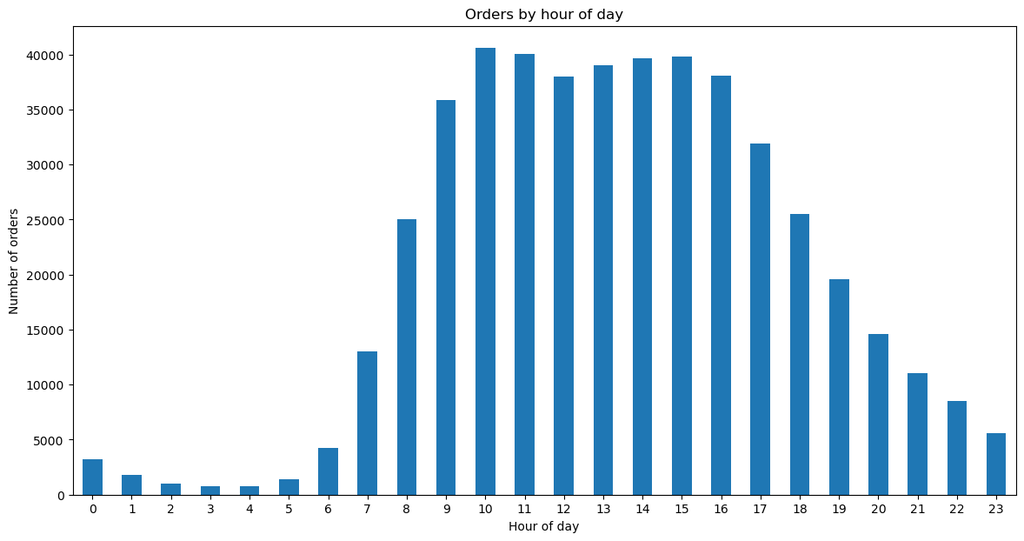

```python
# What time of day do people shop for groceries?
shopping_time = orders['order_hour_of_day'].value_counts().sort_index()

# Visualize with a bar plot
shopping_time.plot(kind='bar', xlabel='Hour of day', ylabel='Number of orders', title='Orders by hour of day', rot=0, figsize=(14,7))
plt.show()
```

Most orders occur between 9:00 AM and 5:00 PM, with peaks at 10:00 AM and 3:00 PM

### Shopping Patterns by Day of Week

Analyzing order distribution across days of the week to understand weekly shopping patterns and identify high-traffic days.

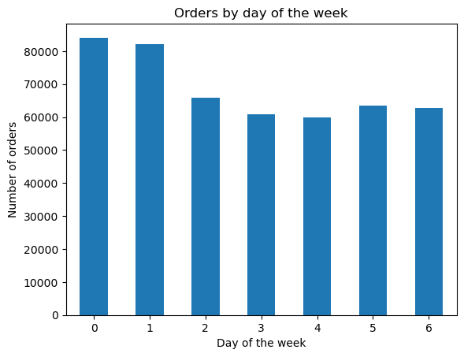

```python
# What day of the week do people shop for groceries?
shopping_day = orders['order_dow'].value_counts().sort_index()

# Visualize with a bar plot
shopping_day.plot(kind='bar', xlabel='Day of the week', ylabel='Number of orders', title='Orders by day of the week', rot=0)
plt.show()
```

The data dictionary does not state which integer corresponds to which day of the week. Assuming Sunday = 0, then people place more orders at the beginning of the week (Sunday and Monday).

### Order Frequency Analysis

Examining the time intervals between consecutive orders to understand customer purchasing cycles and reorder patterns.

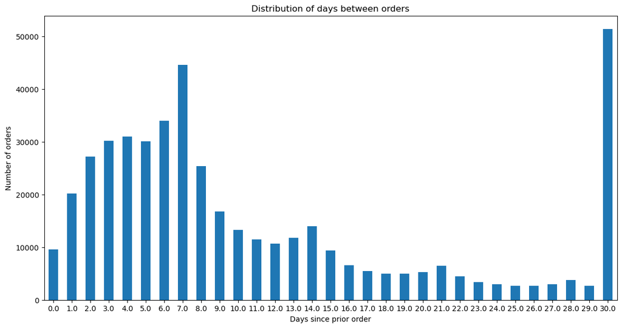

```python
# How long do people wait until placing another order?
order_duration = orders['days_since_prior_order'].value_counts().sort_index()

# Visualize with a bar plot
order_duration.plot(kind='bar', xlabel='Days since prior order', ylabel='Number of orders', title='Distribution of days between orders', rot=0, figsize=(14,7))
plt.show()
```

The 0 values probably correspond to customers who placed more than one order on the same day.

The max value of 30 days and the high spike at that value is puzzling though. The spike might be explained by people who set up recurring subscriptions to automatically order once a month. But that doesn't explain why there are no values above 30 days. I would expect many customers to place orders less often than once a month. Maybe those customers were intentionally excluded from the dataset.

Disregarding the spike at 30 days, most people wait between 2 to 10 days in between orders. The most common wait time is 7 days. In other words, it's common for people to place weekly grocery orders. Interestingly, in the tail of the distribution we also see small spikes at 14, 21, and 28 days. These would correspond to orders every 2, 3, or 4 weeks.

# Deep Dive: Customer Behavior Insights

### Comparative Analysis: Weekday vs Weekend Shopping Patterns

Comparing order time distributions between Wednesday (weekday) and Saturday (weekend) to identify behavioral differences that could inform operational and marketing strategies.

```python
# Create masks for Wednesday (3) and Saturday (6)
wednesday_orders = orders[orders['order_dow'] == 3]
saturday_orders = orders[orders['order_dow'] == 6]
```

```python
# Count order hours for Wednesday and Saturday
wednesday_order_hours = wednesday_orders['order_hour_of_day'].value_counts().sort_index()
saturday_order_hours = saturday_orders['order_hour_of_day'].value_counts().sort_index()
```

```python
# Combine into a single DataFrame
wed_sat_compare = pd.concat([wednesday_order_hours, saturday_order_hours], axis=1, keys=['Wednesday', 'Saturday'])
wed_sat_compare
```

| order_hour_of_day | Wednesday | Saturday |
| --- | --- | --- |
| 0 | 373 | 464 |
| 1 | 215 | 254 |
| 2 | 106 | 177 |
| 3 | 101 | 125 |
| 4 | 108 | 118 |
| 5 | 170 | 161 |
| 6 | 643 | 451 |
| 7 | 1732 | 1619 |
| 8 | 3125 | 3246 |
| 9 | 4490 | 4311 |
| 10 | 5026 | 4919 |
| 11 | 5004 | 5116 |
| 12 | 4688 | 5132 |
| 13 | 4674 | 5323 |
| 14 | 4774 | 5375 |
| 15 | 5163 | 5188 |
| 16 | 4976 | 5029 |
| 17 | 4175 | 4295 |
| 18 | 3463 | 3338 |
| 19 | 2652 | 2610 |
| 20 | 1917 | 1847 |
| 21 | 1450 | 1473 |
| 22 | 1154 | 1185 |
| 23 | 718 | 893 |

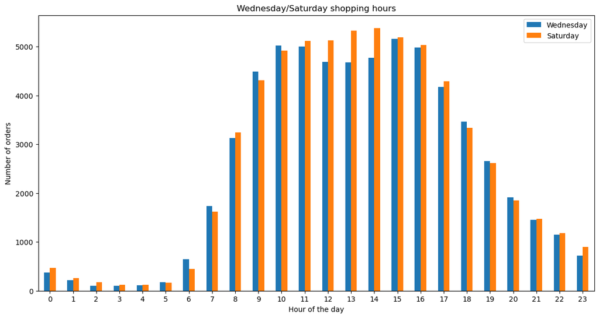

```python
# Plot bar charts for both days
wed_sat_compare.plot(kind='bar', xlabel='Hour of the day', ylabel='Number of orders', title='Wednesday/Saturday shopping hours', rot=0, figsize=(14,7))
plt.show()
```

There's a small dip from 11h to 13h on Wednesdays. This dip is absent on Saturdays. Maybe this dip can be attributed to people who don't use Instacart because they have lunch somewhere between 11h and 13h.

### Customer Engagement Analysis

Analyzing the distribution of orders per customer to understand user engagement levels and identify customer retention patterns.

```python
# Group by user_id and count orders
orders_per_customer = orders.groupby('user_id')['order_id'].count().sort_values()
```

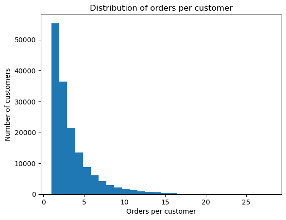

```python
# Visualize with a histogram
plt.hist(orders_per_customer, bins=28)
plt.xlabel('Orders per customer')
plt.ylabel('Number of customers')
plt.title('Distribution of orders per customer')
plt.show()
```

Most customers in the dataset have placed between 1 and 10 orders, with number of orders per customer sharply decreasing after just 1 order.

### Product Popularity Rankings

Identifying the top 20 most frequently ordered products to understand customer preferences and inform inventory optimization.

```python
# Merge order_products with products to get product names
products_merge = order_products.merge(products, on='product_id')

# Group by product_id and product_name, count occurrences
product_popularity = products_merge.groupby(['product_id', 'product_name']).size().sort_values(ascending=False).head(20)
```

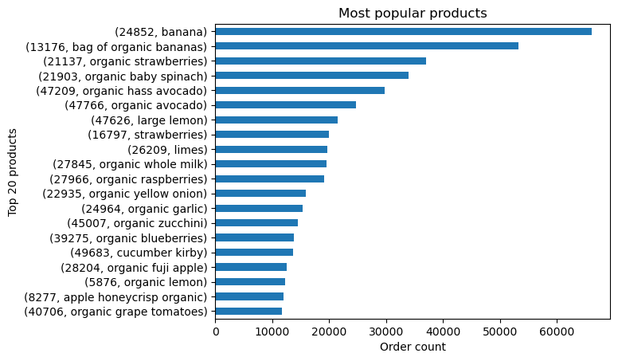

```python
# Visualize the top 20 products
product_popularity.plot(kind='barh') # Use a horizontal bar chart to display products as a list
plt.gca().invert_yaxis() # List most popular products from top down
plt.title('Most popular products')
plt.xlabel('Order count')
plt.ylabel('Top 20 products')
plt.show()
```

```python
# Display as a table
product_popularity_df = product_popularity.reset_index() # Reset index to default and create new column for existing index
product_popularity_df.columns = ['product_id', 'product_name', 'order_count'] # Label all columns
product_popularity_df
```

|  | product_id | product_name | order_count |
| --- | --- | --- | --- |
| 0 | 24852 | banana | 66050 |
| 1 | 13176 | bag of organic bananas | 53297 |
| 2 | 21137 | organic strawberries | 37039 |
| 3 | 21903 | organic baby spinach | 33971 |
| 4 | 47209 | organic hass avocado | 29773 |
| 5 | 47766 | organic avocado | 24689 |
| 6 | 47626 | large lemon | 21495 |
| 7 | 16797 | strawberries | 20018 |
| 8 | 26209 | limes | 19690 |
| 9 | 27845 | organic whole milk | 19600 |
| 10 | 27966 | organic raspberries | 19197 |
| 11 | 22935 | organic yellow onion | 15898 |
| 12 | 24964 | organic garlic | 15292 |
| 13 | 45007 | organic zucchini | 14584 |
| 14 | 39275 | organic blueberries | 13879 |
| 15 | 49683 | cucumber kirby | 13675 |
| 16 | 28204 | organic fuji apple | 12544 |
| 17 | 5876 | organic lemon | 12232 |
| 18 | 8277 | apple honeycrisp organic | 11993 |
| 19 | 40706 | organic grape tomatoes | 11781 |

The top 20 items are all produce, except for the milk. Looks like people want delicious and nutritious!

# Advanced Analysis: Basket Composition and Reorder Behavior

### Basket Size Analysis

Analyzing the distribution of items per order to understand typical basket sizes and shopping behavior patterns.

```python
# Group by order_id and count items in each order
items_per_order = order_products.groupby('order_id')['product_id'].count()
print('Items per order Min:', items_per_order.min(), '\nItems per order Max:', items_per_order.max())
# Count how frequently each order size occurs
order_size_distribution = items_per_order.value_counts().sort_index()
print(order_size_distribution.head(20))
```

```
Items per order Min: 1
Items per order Max: 127
product_id
1     21847
2     26292
3     29046
4     31054
5     31923
6     31698
7     30822
8     28539
9     25742
10    23248
11    20406
12    18539
13    16497
14    14472
15    12696
16    11465
17    10002
18     8726
19     7612
20     6771
Name: count, dtype: int64
```

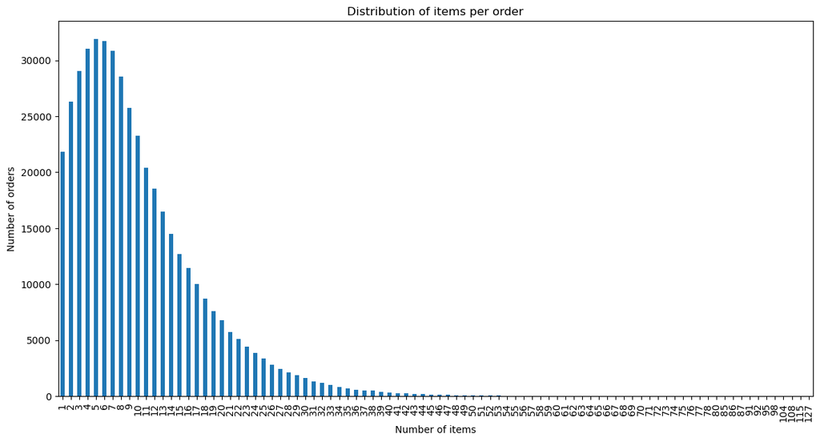

```python
# Visualize the full distribution
order_size_distribution.plot(kind="bar", xlabel='Number of items', ylabel='Number of orders', title='Distribution of items per order', figsize=(14,7))
plt.show()
```

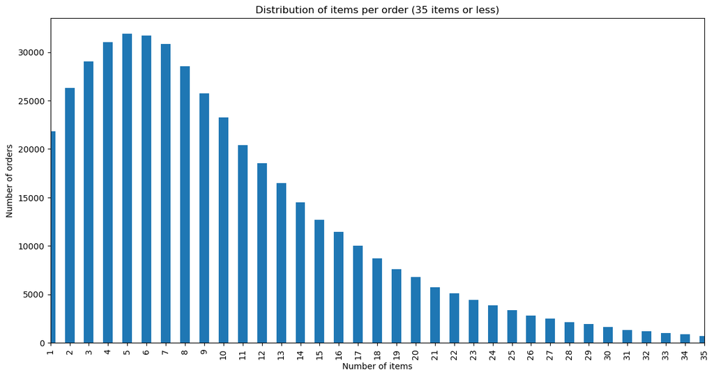

```python
# Plot orders with fewer than 35 items for better visualization
order_size_distribution.plot(kind="bar", xlabel='Number of items', ylabel='Number of orders', title='Distribution of items per order (35 items or less)', figsize=(14,7))
plt.xlim(0,34)
plt.show()
```

The typical order contains 5 or 6 items, with most orders having between 1 and 20 items.

### Reorder Frequency Analysis

Identifying the most frequently reordered products to understand customer loyalty and product staples.

```python
# Filter for reordered items only
reordered_items = order_products[order_products['reordered'] == 1]

# Merge with products to get product names
reordered_with_names = reordered_items.merge(products, on='product_id')

# Group by product and count reorders
top_reordered = reordered_with_names.groupby(['product_id', 'product_name']).size().sort_values(ascending=False).head(20)
print(top_reordered)
```

```
product_id  product_name
24852       banana                      55763
13176       bag of organic bananas      44450
21137       organic strawberries        28639
21903       organic baby spinach        26233
47209       organic hass avocado        23629
47766       organic avocado             18743
27845       organic whole milk          16251
47626       large lemon                 15044
27966       organic raspberries         14748
16797       strawberries                13945
26209       limes                       13327
22935       organic yellow onion        11145
24964       organic garlic              10411
45007       organic zucchini            10076
49683       cucumber kirby               9538
28204       organic fuji apple           8989
8277        apple honeycrisp organic     8836
39275       organic blueberries          8799
5876        organic lemon                8412
49235       organic half & half          8389
dtype: int64
```

**Methodology Note:** Analysis uses the complete product dataset (prior to deduplication) and groups by product name to capture all product IDs associated with each product, ensuring comprehensive reorder counting.

```python
# Merge with products df saved before the dropped duplicate rows to ensure all product ids are accounted for
reordered_with_names = reordered_items.merge(products_before_drop, on='product_id')

# Show some products have multiple IDs
id_per_product = reordered_with_names.groupby(['product_name'])['product_id'].nunique().sort_values(ascending=False).head(10)
print('IDs per product shows some products with multiple IDs:\n', id_per_product)

# Group by product and count reorders
top_reordered = reordered_with_names.groupby(['product_name']).size().sort_values(ascending=False).head(20) # Group only by product_name to count multiply product_ids with the same product_name together
print()
print('This list groups only by product name to include all IDs for each product:\n', top_reordered)
```

```
IDs per product shows some products with multiple IDs:
 product_name
unknown                                  508
green tea with ginseng and honey           3
chopped garlic in water                    2
spring water body wash                     2
cream of tartar                            2
cream of mushroom soup                     2
aged balsamic vinegar of modena            2
organic balsamic vinegar of modena         2
family size lasagna with meat & sauce      2
cream of celery condensed soup             2
Name: product_id, dtype: int64

This list groups only by product name to include all IDs for each product:
 product_name
banana                      55763
bag of organic bananas      44450
organic strawberries        28639
organic baby spinach        26233
organic hass avocado        23629
organic avocado             18743
organic whole milk          16251
large lemon                 15044
organic raspberries         14748
strawberries                13945
limes                       13327
organic yellow onion        11145
organic garlic              10411
organic zucchini            10076
cucumber kirby               9538
organic fuji apple           8989
apple honeycrisp organic     8836
organic blueberries          8799
organic lemon                8412
organic half & half          8389
dtype: int64
```

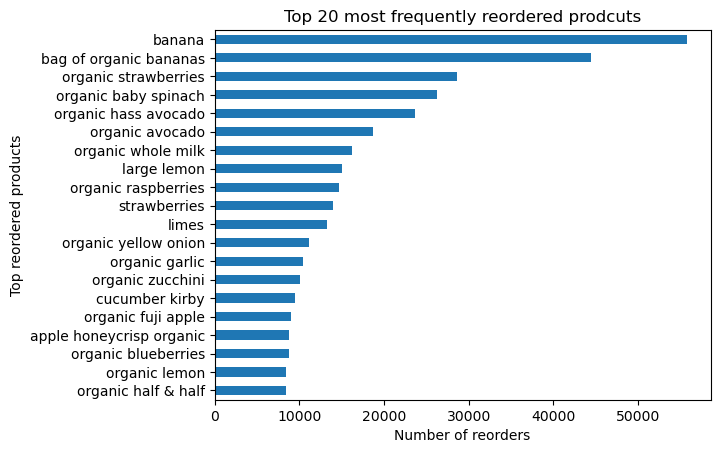

```python
# Visualize top 20 reordered items
top_reordered.plot(kind='barh') # Use horizontal bar chart to diplay items list
plt.gca().invert_yaxis() # List the items with most reordered at the top
plt.xlabel('Number of reorders')
plt.ylabel('Top reordered products')
plt.title('Top 20 most frequently reordered prodcuts')
plt.show()
```

```python
# Display as a table
top_reordered_df = top_reordered.reset_index() # Reset the index to default and create a new column for the existing index
top_reordered_df.columns = ['product_name', 'reorder_count'] # Label the column names
top_reordered_df
```

|  | product_name | reorder_count |
| --- | --- | --- |
| 0 | banana | 55763 |
| 1 | bag of organic bananas | 44450 |
| 2 | organic strawberries | 28639 |
| 3 | organic baby spinach | 26233 |
| 4 | organic hass avocado | 23629 |
| 5 | organic avocado | 18743 |
| 6 | organic whole milk | 16251 |
| 7 | large lemon | 15044 |
| 8 | organic raspberries | 14748 |
| 9 | strawberries | 13945 |
| 10 | limes | 13327 |
| 11 | organic yellow onion | 11145 |
| 12 | organic garlic | 10411 |
| 13 | organic zucchini | 10076 |
| 14 | cucumber kirby | 9538 |
| 15 | organic fuji apple | 8989 |
| 16 | apple honeycrisp organic | 8836 |
| 17 | organic blueberries | 8799 |
| 18 | organic lemon | 8412 |
| 19 | organic half & half | 8389 |

It looks like produce and dairy comprise the most reordered products as well. It makes sense that perishables would be the most reordered items.

### Product Reorder Rate Analysis

Calculating reorder proportions for each product to identify which products generate the highest customer loyalty and repeat purchases.

```python
# Merge order_products with products
products_with_names = order_products.merge(products, on='product_id')

# Group by product and calculate mean of reordered column
reorder_proportion = products_with_names.groupby(['product_id', 'product_name'])['reordered'].mean().sort_values(ascending=False)

# Convert to DataFrame and display top products
reorder_proportion_df = reorder_proportion.reset_index()
reorder_proportion_df.columns = ['product_id', 'product_name', 'reorder_proportion']
reorder_proportion_df.head(20)
```

|  | product_id | product_name | reorder_proportion |
| --- | --- | --- | --- |
| 0 | 49431 | pretzels- mighty minis | 1.0 |
| 1 | 49662 | bacon cheddar pretzel pieces | 1.0 |
| 2 | 6409 | 100% juice cranberry | 1.0 |
| 3 | 6433 | raw veggie wrappers | 1.0 |
| 4 | 49432 | bonbon bar | 1.0 |
| 5 | 49661 | porto | 1.0 |
| 6 | 6490 | vitamin d3 1000 iu in extra virgin olive oil s... | 1.0 |
| 7 | 49657 | cabernet tomatoes | 1.0 |
| 8 | 6530 | organic popped corn simply salted | 1.0 |
| 9 | 49639 | pecans- maple- premium blend | 1.0 |
| 10 | 6189 | meat snacks sriracha beef jerky | 1.0 |
| 11 | 6389 | freshly squeezed lemonade | 1.0 |
| 12 | 49530 | ground sesame tahina | 1.0 |
| 13 | 49589 | spray red honeysuckle nectar air freshener | 1.0 |
| 14 | 49601 | pomegranate gummy bears | 1.0 |
| 15 | 49619 | opo squash | 1.0 |
| 16 | 49625 | golden wheat deep cleanse shampoo | 1.0 |
| 17 | 49430 | cookie con amore jelly cookies | 1.0 |
| 18 | 26555 | raspberry sorbet with dark chocolate bars | 1.0 |
| 19 | 26625 | gravy- country-style sausage | 1.0 |

**Methodology Note:** Using pre-deduplicated product data grouped by product name to ensure accurate reorder rate calculations across all product variants.

```python
# Merge with products dataframe saved before the dropped duplicate rows to ensure all product ids are accounted for
products_with_names = order_products.merge(products_before_drop, on='product_id')

# Group by product and calculate mean of reordered column
reorder_proportion = products_with_names.groupby(['product_name'])['reordered'].mean().sort_values(ascending=False)

# Convert to DataFrame and display top products
reorder_proportion_df = reorder_proportion.reset_index()
reorder_proportion_df.columns = ['product_name', 'reorder_proportion']
reorder_proportion_df.head(20)
```

|  | product_name | reorder_proportion |
| --- | --- | --- |
| 0 | echo caviar | 1.0 |
| 1 | zinfandel dry creek | 1.0 |
| 2 | (70% juice!) mountain raspberry juice squeeze | 1.0 |
| 3 | apple butter spread | 1.0 |
| 4 | apple berry sauce on the go pouches | 1.0 |
| 5 | appetizers for cats steamed wild alaskan salmon | 1.0 |
| 6 | steamables golden potatoes | 1.0 |
| 7 | steamfresh garlic parm peas | 1.0 |
| 8 | steamfresh protein italian style | 1.0 |
| 9 | steel cut with protein maple & brown sugar oat... | 1.0 |
| 10 | dual scented oil refill- hawaiian aloha | 1.0 |
| 11 | dusk deodorant milled bar soap | 1.0 |
| 12 | dry sake | 1.0 |
| 13 | zzzquil vanilla cherry nighttime liquid sleep aid | 1.0 |
| 14 | sidekicks strawberry shake | 1.0 |
| 15 | sierra cedar incense | 1.0 |
| 16 | super fruit | 1.0 |
| 17 | super grains tabbouleh | 1.0 |
| 18 | alpo gravy cravers variety pack dog food | 1.0 |
| 19 | ezekial 4:9 organic sprouted blueberry waffles | 1.0 |

```python
# Display products sorted by product_name
reorder_proportion_df.sort_values('product_name').head(20)
```

|  | product_name | reorder_proportion |
| --- | --- | --- |
| 30018 | #2 coffee filters | 0.254545 |
| 41396 | #2 cone white coffee filters | 0.000000 |
| 41387 | #2 mechanical pencils | 0.000000 |
| 25048 | #4 natural brown coffee filters | 0.358974 |
| 19457 | & go! hazelnut spread + pretzel sticks | 0.466667 |
| 2 | (70% juice!) mountain raspberry juice squeeze | 1.000000 |
| 21360 | +energy black cherry vegetable & fruit juice | 0.428571 |
| 10813 | 0 calorie acai raspberry water beverage | 0.583333 |
| 2049 | 0 calorie fuji apple pear water beverage | 0.833333 |
| 2672 | 0 calorie strawberry dragonfruit water beverage | 0.782609 |
| 7917 | 0% fat black cherry greek yogurt y | 0.636364 |
| 8630 | 0% fat blueberry greek yogurt | 0.623377 |
| 4984 | 0% fat free organic milk | 0.694301 |
| 14090 | 0% fat greek yogurt black cherry on the bottom | 0.526316 |
| 5245 | 0% fat greek yogurt vanilla | 0.687500 |
| 6930 | 0% fat organic greek vanilla yogurt | 0.665339 |
| 23753 | 0% fat peach greek yogurt | 0.388889 |
| 2806 | 0% fat strawberry greek yogurt | 0.775510 |
| 11062 | 0% fat superfruits greek yogurt | 0.579439 |
| 8157 | 0% fat vanilla greek yogurt | 0.631579 |

```python
# Show summary statistics
print('Summary statistics for products reorder proportion:\n', reorder_proportion_df['reorder_proportion'].describe())
```

```
Summary statistics for products reorder proportion:
 count    44518.000000
mean         0.389485
std          0.270599
min          0.000000
25%          0.171645
50%          0.413043
75%          0.578425
max          1.000000
Name: reorder_proportion, dtype: float64
```

### Customer Reorder Behavior Analysis

Analyzing individual customer reorder rates to segment users by loyalty levels and identify retention patterns.

```python
# Merge order_products with orders to get customer information
customer_orders = order_products.merge(orders, on='order_id')

# Group by user_id and calculate mean of reordered column
customer_reorder_proportion = customer_orders.groupby('user_id')['reordered'].mean().sort_values(ascending=False)

# Convert to DataFrame
customer_reorder_df = customer_reorder_proportion.reset_index()
customer_reorder_df.columns = ['user_id', 'reorder_proportion']
customer_reorder_df.head(20)
```

|  | user_id | reorder_proportion |
| --- | --- | --- |
| 0 | 206164 | 1.0 |
| 1 | 17973 | 1.0 |
| 2 | 196795 | 1.0 |
| 3 | 196792 | 1.0 |
| 4 | 196791 | 1.0 |
| 5 | 18048 | 1.0 |
| 6 | 17849 | 1.0 |
| 7 | 196759 | 1.0 |
| 8 | 135680 | 1.0 |
| 9 | 136211 | 1.0 |
| 10 | 136206 | 1.0 |
| 11 | 135720 | 1.0 |
| 12 | 135804 | 1.0 |
| 13 | 135800 | 1.0 |
| 14 | 135797 | 1.0 |
| 15 | 136156 | 1.0 |
| 16 | 135825 | 1.0 |
| 17 | 88 | 1.0 |
| 18 | 135820 | 1.0 |
| 19 | 136294 | 1.0 |

```
Summary statistics for customer reorder proportion:
 count    149626.000000
mean          0.494853
std           0.292685
min           0.000000
25%           0.272727
50%           0.500000
75%           0.724138
max           1.000000
Name: reorder_proportion, dtype: float64
```

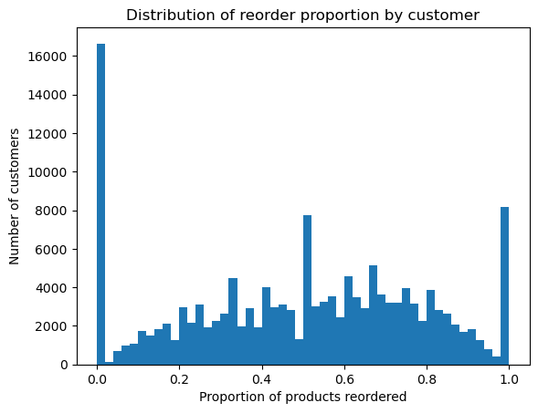

```python
# Show summary statistics for customer reorder proportions
print('Summary statistics for customer reorder proportion:\n', customer_reorder_df['reorder_proportion'].describe())

# Visualize the distribution
plt.hist(customer_reorder_df['reorder_proportion'], bins=50)
plt.xlabel('Proportion of products reordered')
plt.ylabel('Number of customers')
plt.title('Distribution of reorder proportion by customer')
plt.show()
```

### Cart Priority Analysis

Identifying products most frequently added to the cart first to understand shopping priorities and potential app/website layout influences.

```python
# Merge order_products with products
first_items = order_products[order_products['add_to_cart_order'] == 1].merge(products, on='product_id')

# Group by product and count occurrences
top_first_items = first_items.groupby(['product_id', 'product_name']).size().sort_values(ascending=False).head(20)
print(top_first_items)
```

```
product_id  product_name
24852       banana                         15562
13176       bag of organic bananas         11026
27845       organic whole milk              4363
21137       organic strawberries            3946
47209       organic hass avocado            3390
21903       organic baby spinach            3336
47766       organic avocado                 3044
19660       spring water                    2336
16797       strawberries                    2308
27966       organic raspberries             2024
44632       sparkling water grapefruit      1914
49235       organic half & half             1797
47626       large lemon                     1737
196         soda                            1733
38689       organic reduced fat milk        1397
26209       limes                           1370
12341       hass avocados                   1340
5785        organic reduced fat 2% milk     1310
27086       half & half                     1309
43352       raspberries                     1246
dtype: int64
```

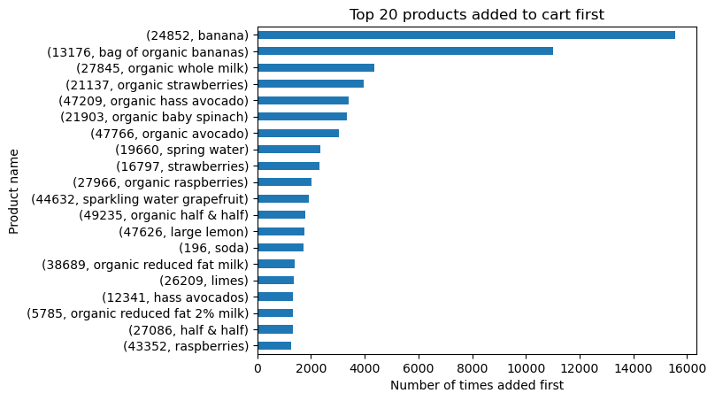

```python
# Visualize top 20 first-in-cart items
top_first_items.plot(kind='barh')
plt.gca().invert_yaxis()
plt.xlabel('Number of times added first')
plt.ylabel('Product name')
plt.title('Top 20 products added to cart first')
plt.show()
```

```python
# Display as a table
top_first_items_df = top_first_items.reset_index()
top_first_items_df.columns = ['product_id', 'product_name', 'first_in_cart_count']
top_first_items_df
```

|  | product_id | product_name | first_in_cart_count |
| --- | --- | --- | --- |
| 0 | 24852 | banana | 15562 |
| 1 | 13176 | bag of organic bananas | 11026 |
| 2 | 27845 | organic whole milk | 4363 |
| 3 | 21137 | organic strawberries | 3946 |
| 4 | 47209 | organic hass avocado | 3390 |
| 5 | 21903 | organic baby spinach | 3336 |
| 6 | 47766 | organic avocado | 3044 |
| 7 | 19660 | spring water | 2336 |
| 8 | 16797 | strawberries | 2308 |
| 9 | 27966 | organic raspberries | 2024 |
| 10 | 44632 | sparkling water grapefruit | 1914 |
| 11 | 49235 | organic half & half | 1797 |
| 12 | 47626 | large lemon | 1737 |
| 13 | 196 | soda | 1733 |
| 14 | 38689 | organic reduced fat milk | 1397 |
| 15 | 26209 | limes | 1370 |
| 16 | 12341 | hass avocados | 1340 |
| 17 | 5785 | organic reduced fat 2% milk | 1310 |
| 18 | 27086 | half & half | 1309 |
| 19 | 43352 | raspberries | 1246 |

The products that are most often placed into the cart first are produce, dairy, and beverages such as soda or water. I couldn't really say why that is without experience using Instacart because this could have more to do with app design than properties of the products. I do notice that there is considerable overlap between this result and the previous result for most popular and most reordered item types. It could simply be that the app prioritizes popular items as the first suggested purchases, so it happens to be more convenient for customers to place these items in their cart first.

# Summary and Business Recommendations

## Key Findings

### Shopping Behavior Patterns

- **Peak Shopping Hours**: Orders concentrate between 9:00 AM and 5:00 PM, with notable peaks at 10:00 AM and 3:00 PM
- **Weekly Patterns**: Sunday and Monday show the highest order volumes (assuming Sunday = 0)
- **Reorder Cycles**: Most customers reorder within 7 days, with secondary spikes at 14, 21, and 28-day intervals suggesting weekly and multi-week shopping routines

### Customer Engagement

- **Order Frequency**: Most customers place between 1-10 orders, with sharp drop-off after the first order, suggesting retention opportunities
- **Weekday vs Weekend**: Wednesday shows a midday dip (11h-13h) absent on Saturdays, possibly reflecting work schedule impacts on shopping behavior

## Business Recommendations

### Operational Optimization

1. **Staffing & Inventory**: Allocate resources based on peak hours (10 AM and 3 PM) and high-volume days (Sunday/Monday)
2. **Fresh Product Focus**: Prioritize stock availability for top produce and dairy items, which drive both popularity and reorder rates
3. **Weekend Strategy**: Adjust inventory and fulfillment capacity for weekend orders which show different temporal patterns

### Marketing & Retention

1. **New Customer Onboarding**: Given the sharp drop-off after first orders, implement targeted retention campaigns for new users
2. **Subscription Services**: Leverage the 7-day reorder cycle to promote weekly subscription options for staple items
3. **Time-Based Promotions**: Schedule promotional campaigns during peak shopping windows for maximum visibility

### Product Recommendations

1. **Personalized Suggestions**: Utilize reorder patterns to predict customer needs and suggest frequently reordered items
2. **Cart Optimization**: Feature popular first-cart items (produce, dairy, beverages) prominently in the app interface
3. **Basket Building**: Encourage larger basket sizes through bundling strategies, given that most orders contain fewer than 10 items

## Next Steps for Analysis

- Investigate the 30-day maximum in `days_since_prior_order` to understand data collection methodology
- Segment customers by reorder behavior to develop targeted retention strategies
- Analyze seasonal trends if temporal data is available
- Examine correlation between basket size and customer lifetime value
- Explore department-level performance beyond individual products